# heatmaps-with-libs8-11DEGlist

Rmd to make heatmaps. Using list of DEGs from comparison of libraries 8-11 based on infection taking temperature into account contrasting the two temperatures (list of 123 DEGs). will map those genes in the individual crab samples RNAseq data. These might be kind of weird because the individual crab RNAseq results were not used in assembling transcriptome v 3.1.

### Set up R Markdown document

```r
library(pheatmap)
library(dplyr)
library(RColorBrewer)
```

Read in normalized counts from transcriptome V : (individual RNAseq data was not used in transcriptome v 3.1)

```r
norm_counts <- read.delim("../data/salmon.isoform.TMM.EXPR.matrix")
head(norm_counts)
```

```
##                          X X294_quant X254_quant X280_quant X485_quant
## 1  TRINITY_DN5772_c0_g1_i1      0.000      0.000      0.000      0.000
## 2  TRINITY_DN2201_c0_g1_i1      0.406      0.000      1.537      0.000
## 3  TRINITY_DN4656_c0_g1_i1      2.445      7.675      1.673      3.277
## 4  TRINITY_DN7591_c0_g1_i1      3.369      1.049      1.366      0.444
## 5  TRINITY_DN6285_c0_g1_i4      0.000      0.000      0.000      1.806
## 6 TRINITY_DN28918_c0_g1_i1      0.000      0.000      0.000      0.000
##   X481_quant X173_quant X222_quant X151_quant X272_quant X132_quant X127_quant
## 1      0.000      0.000      0.000      0.000          0       0.00      0.000
## 2      0.000      0.000      0.817      0.000          0       0.00      0.000
## 3      2.057     28.523      2.074      4.561          0       2.39      2.925
## 4      6.289      0.000      4.666      2.383          0       0.00     10.800
## 5      0.000      0.000      0.000      0.000          0       0.00      0.000
## 6      1.520      0.000      0.000      0.000          0       0.00      0.919
##   X73_quant X427_quant X118_quant X334_quant X349_quant X425_quant X178_quant
## 1         0          0      0.000      0.000          0          0      0.000
## 2         0          0      0.000      0.000          0          0      0.000
## 3         0          0      2.047      1.627          0          0      6.384
## 4         0          0      1.650      0.000          0          0      0.839
## 5         0          0      0.000      0.000          0          0      0.000
## 6         0          0      0.000      0.000          0          0      1.990
##   X72_quant X463_quant X221_quant X445_quant X359_quant X113_quant
## 1     0.000          0          0      0.000      1.976      0.000
## 2     0.000          0          0      7.232      0.000      2.599
## 3     2.853          0          0      2.853      4.987      2.019
## 4     0.000          0          0      8.787      5.773      8.427
## 5     0.000          0          0      1.397      0.000      0.000
## 6     0.000          0          0      0.000      0.000      0.000
```

Rename columns:

```r
colnames(norm_counts) <- c("Trinity_ID", "CrabH_2", "CrabE_2", "CrabI_2", "CrabC_17", "CrabB_17", "CrabG_0", "CrabF_2", "CrabE_0", "CrabG_2", "CrabC_0", "CrabI_0", "CrabD_0", "CrabD_17", "CrabB_0", "CrabC_2", "CrabB_2", "CrabF_17", "CrabA_0", "CrabH_0", "CrabA_17", "CrabD_2", "CrabE_17", "CrabA_2", "CrabF_0")
head(norm_counts)
```

```
##                 Trinity_ID CrabH_2 CrabE_2 CrabI_2 CrabC_17 CrabB_17 CrabG_0
## 1  TRINITY_DN5772_c0_g1_i1   0.000   0.000   0.000    0.000    0.000   0.000
## 2  TRINITY_DN2201_c0_g1_i1   0.406   0.000   1.537    0.000    0.000   0.000
## 3  TRINITY_DN4656_c0_g1_i1   2.445   7.675   1.673    3.277    2.057  28.523
## 4  TRINITY_DN7591_c0_g1_i1   3.369   1.049   1.366    0.444    6.289   0.000
## 5  TRINITY_DN6285_c0_g1_i4   0.000   0.000   0.000    1.806    0.000   0.000
## 6 TRINITY_DN28918_c0_g1_i1   0.000   0.000   0.000    0.000    1.520   0.000
##   CrabF_2 CrabE_0 CrabG_2 CrabC_0 CrabI_0 CrabD_0 CrabD_17 CrabB_0 CrabC_2
## 1   0.000   0.000       0    0.00   0.000       0        0   0.000   0.000
## 2   0.817   0.000       0    0.00   0.000       0        0   0.000   0.000
## 3   2.074   4.561       0    2.39   2.925       0        0   2.047   1.627
## 4   4.666   2.383       0    0.00  10.800       0        0   1.650   0.000
## 5   0.000   0.000       0    0.00   0.000       0        0   0.000   0.000
## 6   0.000   0.000       0    0.00   0.919       0        0   0.000   0.000
##   CrabB_2 CrabF_17 CrabA_0 CrabH_0 CrabA_17 CrabD_2 CrabE_17 CrabA_2 CrabF_0
## 1       0        0   0.000   0.000        0       0    0.000   1.976   0.000
## 2       0        0   0.000   0.000        0       0    7.232   0.000   2.599
## 3       0        0   6.384   2.853        0       0    2.853   4.987   2.019
## 4       0        0   0.839   0.000        0       0    8.787   5.773   8.427
## 5       0        0   0.000   0.000        0       0    1.397   0.000   0.000
## 6       0        0   1.990   0.000        0       0    0.000   0.000   0.000
```

## Read in DEG list from temperature contrast after getting DEGs from infection taking temp into account (DESeq-libraries8-11.Rmd)

Read in DEG list (123)

```r
contrasttemp_degs <- read.delim("../analyses/DEGlist-contrast_temp-libs8-11.txt", header = TRUE)
head(contrasttemp_degs)
```

```
##                 Trinity_ID   baseMean log2FoldChange     lfcSE      stat
## 1 TRINITY_DN12600_c0_g1_i2   48.25267       8.918859 2.1376058  4.172359
## 2 TRINITY_DN12397_c1_g1_i1   58.71905      -9.373273 2.0352048 -4.605567
## 3   TRINITY_DN428_c0_g1_i6 1246.63027       1.699913 0.4042303  4.205308
## 4 TRINITY_DN10286_c0_g1_i1  153.54567       3.234433 0.8644983  3.741399
## 5  TRINITY_DN4702_c0_g1_i2   83.37100       9.700602 1.8816717  5.155311
## 6 TRINITY_DN1091_c0_g1_i16   62.10922      -9.323208 2.0112179 -4.635603
##        pvalue        padj
## 1 0.000030100 0.009465915
## 2 0.000004110 0.002472057
## 3 0.000026100 0.008501710
## 4 0.000182999 0.032322199
## 5 0.000000253 0.000330265
## 6 0.000003560 0.002270095
```

`join` with norm_counts by “Trinity_ID”

```r
contrasttemp_degs_counts <- left_join(norm_counts, contrasttemp_degs, by = "Trinity_ID")
head(contrasttemp_degs_counts)
```

```
##                 Trinity_ID CrabH_2 CrabE_2 CrabI_2 CrabC_17 CrabB_17 CrabG_0
## 1  TRINITY_DN5772_c0_g1_i1   0.000   0.000   0.000    0.000    0.000   0.000
## 2  TRINITY_DN2201_c0_g1_i1   0.406   0.000   1.537    0.000    0.000   0.000
## 3  TRINITY_DN4656_c0_g1_i1   2.445   7.675   1.673    3.277    2.057  28.523
## 4  TRINITY_DN7591_c0_g1_i1   3.369   1.049   1.366    0.444    6.289   0.000
## 5  TRINITY_DN6285_c0_g1_i4   0.000   0.000   0.000    1.806    0.000   0.000
## 6 TRINITY_DN28918_c0_g1_i1   0.000   0.000   0.000    0.000    1.520   0.000
##   CrabF_2 CrabE_0 CrabG_2 CrabC_0 CrabI_0 CrabD_0 CrabD_17 CrabB_0 CrabC_2
## 1   0.000   0.000       0    0.00   0.000       0        0   0.000   0.000
## 2   0.817   0.000       0    0.00   0.000       0        0   0.000   0.000
## 3   2.074   4.561       0    2.39   2.925       0        0   2.047   1.627
## 4   4.666   2.383       0    0.00  10.800       0        0   1.650   0.000
## 5   0.000   0.000       0    0.00   0.000       0        0   0.000   0.000
## 6   0.000   0.000       0    0.00   0.919       0        0   0.000   0.000
##   CrabB_2 CrabF_17 CrabA_0 CrabH_0 CrabA_17 CrabD_2 CrabE_17 CrabA_2 CrabF_0
## 1       0        0   0.000   0.000        0       0    0.000   1.976   0.000
## 2       0        0   0.000   0.000        0       0    7.232   0.000   2.599
## 3       0        0   6.384   2.853        0       0    2.853   4.987   2.019
## 4       0        0   0.839   0.000        0       0    8.787   5.773   8.427
## 5       0        0   0.000   0.000        0       0    1.397   0.000   0.000
## 6       0        0   1.990   0.000        0       0    0.000   0.000   0.000
##   baseMean log2FoldChange lfcSE stat pvalue padj
## 1       NA             NA    NA   NA     NA   NA
## 2       NA             NA    NA   NA     NA   NA
## 3       NA             NA    NA   NA     NA   NA
## 4       NA             NA    NA   NA     NA   NA
## 5       NA             NA    NA   NA     NA   NA
## 6       NA             NA    NA   NA     NA   NA
```

```r
contrasttemp_degs_counts_match <- filter(contrasttemp_degs_counts, baseMean != "NA")
head(contrasttemp_degs_counts_match)
```

```
##                 Trinity_ID CrabH_2 CrabE_2 CrabI_2 CrabC_17 CrabB_17 CrabG_0
## 1   TRINITY_DN276_c0_g1_i3   0.000   2.162   0.000    0.000    0.000   0.000
## 2 TRINITY_DN12397_c1_g1_i1   0.131   0.868  10.636    3.889    2.159   0.392
## 3  TRINITY_DN1968_c0_g1_i3   0.867   5.338   3.504    3.118    0.000   0.000
## 4 TRINITY_DN10286_c0_g1_i1   0.000   0.000   0.000    0.000    1.856   0.000
## 5  TRINITY_DN6714_c0_g1_i3  14.103   0.000   9.355   10.937    9.072   0.000
## 6  TRINITY_DN1536_c0_g1_i1   0.000   0.000  16.174    0.000    0.000   0.000
##   CrabF_2 CrabE_0 CrabG_2 CrabC_0 CrabI_0 CrabD_0 CrabD_17 CrabB_0 CrabC_2
## 1   5.335   1.310   0.000   0.000   5.455       0        0   0.000   0.000
## 2   6.949   1.051   1.038   1.052  10.915       0        0  10.554   0.000
## 3   0.000   1.144   0.000   0.000   3.738       0        0   0.000   0.000
## 4   0.000   0.000   0.000   0.000   0.000       0        0   0.000   0.000
## 5  10.845  17.231   6.010   4.294  15.805       0        0   6.017   0.455
## 6   0.000   0.000   0.000   0.000   0.000       0        0   0.000   0.000
##   CrabB_2 CrabF_17 CrabA_0 CrabH_0 CrabA_17 CrabD_2 CrabE_17 CrabA_2 CrabF_0
## 1   0.000        0   0.000   0.000        0       0    0.000   0.000   0.000
## 2   0.000        0   8.949   0.000        0       0    8.346  11.554   4.703
## 3   0.000        0   0.000   0.000        0       0    1.109   4.575   0.000
## 4   7.156        0   0.000   0.000        0       0    0.000   0.000   0.000
## 5   0.000        0   1.047   1.714        0       0   16.718   7.648  18.134
## 6   0.000        0   0.000   0.000        0       0    0.000   0.000   0.000
##    baseMean log2FoldChange     lfcSE      stat      pvalue        padj
## 1 110.44121      10.113956 1.7874080  5.658448 1.53000e-08 0.000037000
## 2  58.71905      -9.373273 2.0352048 -4.605567 4.11000e-06 0.002472057
## 3 719.68409       1.792908 0.4623374  3.877922 1.05352e-04 0.022612108
## 4 153.54567       3.234433 0.8644983  3.741399 1.82999e-04 0.032322199
## 5  68.20839      -9.616440 1.9647975 -4.894367 9.86000e-07 0.000929026
## 6 792.48283       2.063914 0.5752597  3.587796 3.33485e-04 0.047488440
```

13 rows….

Pull out just the sample count data:

```r
conttempdegs <- select(contrasttemp_degs_counts_match, Trinity_ID, CrabA_0, CrabA_2, CrabA_17, CrabB_0, CrabB_2, CrabB_17, CrabC_0, CrabC_2, CrabC_17, CrabD_0, CrabD_2, CrabD_17, CrabE_0, CrabE_2, CrabE_17, CrabF_0, CrabF_2, CrabF_17, CrabG_0, CrabG_2, CrabH_0, CrabH_2, CrabI_0, CrabI_2)
head(conttempdegs)
```

```
##                 Trinity_ID CrabA_0 CrabA_2 CrabA_17 CrabB_0 CrabB_2 CrabB_17
## 1   TRINITY_DN276_c0_g1_i3   0.000   0.000        0   0.000   0.000    0.000
## 2 TRINITY_DN12397_c1_g1_i1   8.949  11.554        0  10.554   0.000    2.159
## 3  TRINITY_DN1968_c0_g1_i3   0.000   4.575        0   0.000   0.000    0.000
## 4 TRINITY_DN10286_c0_g1_i1   0.000   0.000        0   0.000   7.156    1.856
## 5  TRINITY_DN6714_c0_g1_i3   1.047   7.648        0   6.017   0.000    9.072
## 6  TRINITY_DN1536_c0_g1_i1   0.000   0.000        0   0.000   0.000    0.000
##   CrabC_0 CrabC_2 CrabC_17 CrabD_0 CrabD_2 CrabD_17 CrabE_0 CrabE_2 CrabE_17
## 1   0.000   0.000    0.000       0       0        0   1.310   2.162    0.000
## 2   1.052   0.000    3.889       0       0        0   1.051   0.868    8.346
## 3   0.000   0.000    3.118       0       0        0   1.144   5.338    1.109
## 4   0.000   0.000    0.000       0       0        0   0.000   0.000    0.000
## 5   4.294   0.455   10.937       0       0        0  17.231   0.000   16.718
## 6   0.000   0.000    0.000       0       0        0   0.000   0.000    0.000
##   CrabF_0 CrabF_2 CrabF_17 CrabG_0 CrabG_2 CrabH_0 CrabH_2 CrabI_0 CrabI_2
## 1   0.000   5.335        0   0.000   0.000   0.000   0.000   5.455   0.000
## 2   4.703   6.949        0   0.392   1.038   0.000   0.131  10.915  10.636
## 3   0.000   0.000        0   0.000   0.000   0.000   0.867   3.738   3.504
## 4   0.000   0.000        0   0.000   0.000   0.000   0.000   0.000   0.000
## 5  18.134  10.845        0   0.000   6.010   1.714  14.103  15.805   9.355
## 6   0.000   0.000        0   0.000   0.000   0.000   0.000   0.000  16.174
```

Set Trinity_ID as row names:

```r
rownames(conttempdegs) <- conttempdegs$Trinity_ID #set Trinity IDs as rownames
conttempdegs.heatmap <- conttempdegs[,-1] #remove redundant column
head(conttempdegs.heatmap)
```

```
##                          CrabA_0 CrabA_2 CrabA_17 CrabB_0 CrabB_2 CrabB_17
## TRINITY_DN276_c0_g1_i3     0.000   0.000        0   0.000   0.000    0.000
## TRINITY_DN12397_c1_g1_i1   8.949  11.554        0  10.554   0.000    2.159
## TRINITY_DN1968_c0_g1_i3    0.000   4.575        0   0.000   0.000    0.000
## TRINITY_DN10286_c0_g1_i1   0.000   0.000        0   0.000   7.156    1.856
## TRINITY_DN6714_c0_g1_i3    1.047   7.648        0   6.017   0.000    9.072
## TRINITY_DN1536_c0_g1_i1    0.000   0.000        0   0.000   0.000    0.000
##                          CrabC_0 CrabC_2 CrabC_17 CrabD_0 CrabD_2 CrabD_17
## TRINITY_DN276_c0_g1_i3     0.000   0.000    0.000       0       0        0
## TRINITY_DN12397_c1_g1_i1   1.052   0.000    3.889       0       0        0
## TRINITY_DN1968_c0_g1_i3    0.000   0.000    3.118       0       0        0
## TRINITY_DN10286_c0_g1_i1   0.000   0.000    0.000       0       0        0
## TRINITY_DN6714_c0_g1_i3    4.294   0.455   10.937       0       0        0
## TRINITY_DN1536_c0_g1_i1    0.000   0.000    0.000       0       0        0
##                          CrabE_0 CrabE_2 CrabE_17 CrabF_0 CrabF_2 CrabF_17
## TRINITY_DN276_c0_g1_i3     1.310   2.162    0.000   0.000   5.335        0
## TRINITY_DN12397_c1_g1_i1   1.051   0.868    8.346   4.703   6.949        0
## TRINITY_DN1968_c0_g1_i3    1.144   5.338    1.109   0.000   0.000        0
## TRINITY_DN10286_c0_g1_i1   0.000   0.000    0.000   0.000   0.000        0
## TRINITY_DN6714_c0_g1_i3   17.231   0.000   16.718  18.134  10.845        0
## TRINITY_DN1536_c0_g1_i1    0.000   0.000    0.000   0.000   0.000        0
##                          CrabG_0 CrabG_2 CrabH_0 CrabH_2 CrabI_0 CrabI_2
## TRINITY_DN276_c0_g1_i3     0.000   0.000   0.000   0.000   5.455   0.000
## TRINITY_DN12397_c1_g1_i1   0.392   1.038   0.000   0.131  10.915  10.636
## TRINITY_DN1968_c0_g1_i3    0.000   0.000   0.000   0.867   3.738   3.504
## TRINITY_DN10286_c0_g1_i1   0.000   0.000   0.000   0.000   0.000   0.000
## TRINITY_DN6714_c0_g1_i3    0.000   6.010   1.714  14.103  15.805   9.355
## TRINITY_DN1536_c0_g1_i1    0.000   0.000   0.000   0.000   0.000  16.174
```

ROUND INTEGERS UP:

```r
conttempdegs.heatmap <- round(conttempdegs.heatmap,0)
head(conttempdegs.heatmap)
```

```
##                          CrabA_0 CrabA_2 CrabA_17 CrabB_0 CrabB_2 CrabB_17
## TRINITY_DN276_c0_g1_i3         0       0        0       0       0        0
## TRINITY_DN12397_c1_g1_i1       9      12        0      11       0        2
## TRINITY_DN1968_c0_g1_i3        0       5        0       0       0        0
## TRINITY_DN10286_c0_g1_i1       0       0        0       0       7        2
## TRINITY_DN6714_c0_g1_i3        1       8        0       6       0        9
## TRINITY_DN1536_c0_g1_i1        0       0        0       0       0        0
##                          CrabC_0 CrabC_2 CrabC_17 CrabD_0 CrabD_2 CrabD_17
## TRINITY_DN276_c0_g1_i3         0       0        0       0       0        0
## TRINITY_DN12397_c1_g1_i1       1       0        4       0       0        0
## TRINITY_DN1968_c0_g1_i3        0       0        3       0       0        0
## TRINITY_DN10286_c0_g1_i1       0       0        0       0       0        0
## TRINITY_DN6714_c0_g1_i3        4       0       11       0       0        0
## TRINITY_DN1536_c0_g1_i1        0       0        0       0       0        0
##                          CrabE_0 CrabE_2 CrabE_17 CrabF_0 CrabF_2 CrabF_17
## TRINITY_DN276_c0_g1_i3         1       2        0       0       5        0
## TRINITY_DN12397_c1_g1_i1       1       1        8       5       7        0
## TRINITY_DN1968_c0_g1_i3        1       5        1       0       0        0
## TRINITY_DN10286_c0_g1_i1       0       0        0       0       0        0
## TRINITY_DN6714_c0_g1_i3       17       0       17      18      11        0
## TRINITY_DN1536_c0_g1_i1        0       0        0       0       0        0
##                          CrabG_0 CrabG_2 CrabH_0 CrabH_2 CrabI_0 CrabI_2
## TRINITY_DN276_c0_g1_i3         0       0       0       0       5       0
## TRINITY_DN12397_c1_g1_i1       0       1       0       0      11      11
## TRINITY_DN1968_c0_g1_i3        0       0       0       1       4       4
## TRINITY_DN10286_c0_g1_i1       0       0       0       0       0       0
## TRINITY_DN6714_c0_g1_i3        0       6       2      14      16       9
## TRINITY_DN1536_c0_g1_i1        0       0       0       0       0      16
```

Create heatmap colors:

```r
heatmapPurOr <- RColorBrewer::brewer.pal(11, "PuOr")
```

Going to remove all rows that have “0” for all samples:

```r
noz_conttempdegs.heatmap <- conttempdegs.heatmap[rowSums(conttempdegs.heatmap[, -1] >0) !=0, ]
head(noz_conttempdegs.heatmap)
```

```
##                          CrabA_0 CrabA_2 CrabA_17 CrabB_0 CrabB_2 CrabB_17
## TRINITY_DN276_c0_g1_i3         0       0        0       0       0        0
## TRINITY_DN12397_c1_g1_i1       9      12        0      11       0        2
## TRINITY_DN1968_c0_g1_i3        0       5        0       0       0        0
## TRINITY_DN10286_c0_g1_i1       0       0        0       0       7        2
## TRINITY_DN6714_c0_g1_i3        1       8        0       6       0        9
## TRINITY_DN1536_c0_g1_i1        0       0        0       0       0        0
##                          CrabC_0 CrabC_2 CrabC_17 CrabD_0 CrabD_2 CrabD_17
## TRINITY_DN276_c0_g1_i3         0       0        0       0       0        0
## TRINITY_DN12397_c1_g1_i1       1       0        4       0       0        0
## TRINITY_DN1968_c0_g1_i3        0       0        3       0       0        0
## TRINITY_DN10286_c0_g1_i1       0       0        0       0       0        0
## TRINITY_DN6714_c0_g1_i3        4       0       11       0       0        0
## TRINITY_DN1536_c0_g1_i1        0       0        0       0       0        0
##                          CrabE_0 CrabE_2 CrabE_17 CrabF_0 CrabF_2 CrabF_17
## TRINITY_DN276_c0_g1_i3         1       2        0       0       5        0
## TRINITY_DN12397_c1_g1_i1       1       1        8       5       7        0
## TRINITY_DN1968_c0_g1_i3        1       5        1       0       0        0
## TRINITY_DN10286_c0_g1_i1       0       0        0       0       0        0
## TRINITY_DN6714_c0_g1_i3       17       0       17      18      11        0
## TRINITY_DN1536_c0_g1_i1        0       0        0       0       0        0
##                          CrabG_0 CrabG_2 CrabH_0 CrabH_2 CrabI_0 CrabI_2
## TRINITY_DN276_c0_g1_i3         0       0       0       0       5       0
## TRINITY_DN12397_c1_g1_i1       0       1       0       0      11      11
## TRINITY_DN1968_c0_g1_i3        0       0       0       1       4       4
## TRINITY_DN10286_c0_g1_i1       0       0       0       0       0       0
## TRINITY_DN6714_c0_g1_i3        0       6       2      14      16       9
## TRINITY_DN1536_c0_g1_i1        0       0       0       0       0      16
```

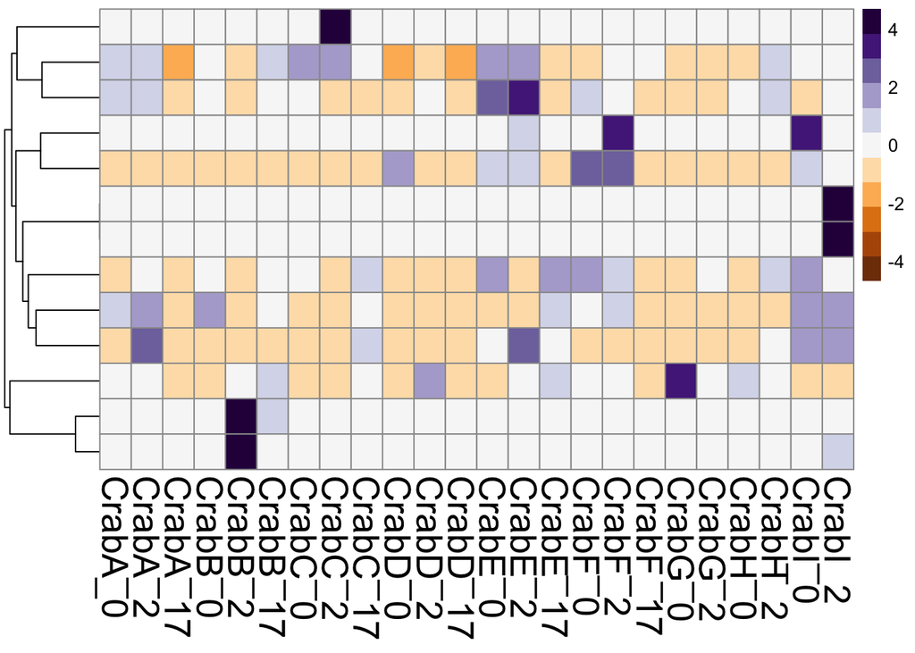

```r
pheatmap(noz_conttempdegs.heatmap, scale = "row", cluster_row = TRUE, cluster_cols = FALSE, clustering_distance_rows = "euclidean", clustering_method = "average", show_rownames = FALSE, show_colnames = TRUE, treeheight_col = 80, legend = TRUE, color = heatmapPurOr, fontsize_col = 20, fontsize_row = 12)
```

### make one of samples ABC and GHI at two time points:

Pull out just the sample count data:

```r
abcghi <- select(contrasttemp_degs_counts_match, Trinity_ID, CrabA_0,  CrabB_0, CrabC_0, CrabG_0, CrabH_0, CrabI_0, CrabA_2, CrabB_2, CrabC_2, CrabG_2, CrabH_2, CrabI_2)
head(abcghi)
```

```
##                 Trinity_ID CrabA_0 CrabB_0 CrabC_0 CrabG_0 CrabH_0 CrabI_0
## 1   TRINITY_DN276_c0_g1_i3   0.000   0.000   0.000   0.000   0.000   5.455
## 2 TRINITY_DN12397_c1_g1_i1   8.949  10.554   1.052   0.392   0.000  10.915
## 3  TRINITY_DN1968_c0_g1_i3   0.000   0.000   0.000   0.000   0.000   3.738
## 4 TRINITY_DN10286_c0_g1_i1   0.000   0.000   0.000   0.000   0.000   0.000
## 5  TRINITY_DN6714_c0_g1_i3   1.047   6.017   4.294   0.000   1.714  15.805
## 6  TRINITY_DN1536_c0_g1_i1   0.000   0.000   0.000   0.000   0.000   0.000
##   CrabA_2 CrabB_2 CrabC_2 CrabG_2 CrabH_2 CrabI_2
## 1   0.000   0.000   0.000   0.000   0.000   0.000
## 2  11.554   0.000   0.000   1.038   0.131  10.636
## 3   4.575   0.000   0.000   0.000   0.867   3.504
## 4   0.000   7.156   0.000   0.000   0.000   0.000
## 5   7.648   0.000   0.455   6.010  14.103   9.355
## 6   0.000   0.000   0.000   0.000   0.000  16.174
```

Set Trinity_ID as row names:

```r
rownames(abcghi) <- abcghi$Trinity_ID #set Trinity IDs as rownames
abcghi.heatmap <- abcghi[,-1] #remove redundant column
head(abcghi.heatmap)
```

```
##                          CrabA_0 CrabB_0 CrabC_0 CrabG_0 CrabH_0 CrabI_0
## TRINITY_DN276_c0_g1_i3     0.000   0.000   0.000   0.000   0.000   5.455
## TRINITY_DN12397_c1_g1_i1   8.949  10.554   1.052   0.392   0.000  10.915
## TRINITY_DN1968_c0_g1_i3    0.000   0.000   0.000   0.000   0.000   3.738
## TRINITY_DN10286_c0_g1_i1   0.000   0.000   0.000   0.000   0.000   0.000
## TRINITY_DN6714_c0_g1_i3    1.047   6.017   4.294   0.000   1.714  15.805
## TRINITY_DN1536_c0_g1_i1    0.000   0.000   0.000   0.000   0.000   0.000
##                          CrabA_2 CrabB_2 CrabC_2 CrabG_2 CrabH_2 CrabI_2
## TRINITY_DN276_c0_g1_i3     0.000   0.000   0.000   0.000   0.000   0.000
## TRINITY_DN12397_c1_g1_i1  11.554   0.000   0.000   1.038   0.131  10.636
## TRINITY_DN1968_c0_g1_i3    4.575   0.000   0.000   0.000   0.867   3.504
## TRINITY_DN10286_c0_g1_i1   0.000   7.156   0.000   0.000   0.000   0.000
## TRINITY_DN6714_c0_g1_i3    7.648   0.000   0.455   6.010  14.103   9.355
## TRINITY_DN1536_c0_g1_i1    0.000   0.000   0.000   0.000   0.000  16.174
```

ROUND INTEGERS UP:

```r
abcghi.heatmap <- round(abcghi.heatmap,0)
head(abcghi.heatmap)
```

```
##                          CrabA_0 CrabB_0 CrabC_0 CrabG_0 CrabH_0 CrabI_0
## TRINITY_DN276_c0_g1_i3         0       0       0       0       0       5
## TRINITY_DN12397_c1_g1_i1       9      11       1       0       0      11
## TRINITY_DN1968_c0_g1_i3        0       0       0       0       0       4
## TRINITY_DN10286_c0_g1_i1       0       0       0       0       0       0
## TRINITY_DN6714_c0_g1_i3        1       6       4       0       2      16
## TRINITY_DN1536_c0_g1_i1        0       0       0       0       0       0
##                          CrabA_2 CrabB_2 CrabC_2 CrabG_2 CrabH_2 CrabI_2
## TRINITY_DN276_c0_g1_i3         0       0       0       0       0       0
## TRINITY_DN12397_c1_g1_i1      12       0       0       1       0      11
## TRINITY_DN1968_c0_g1_i3        5       0       0       0       1       4
## TRINITY_DN10286_c0_g1_i1       0       7       0       0       0       0
## TRINITY_DN6714_c0_g1_i3        8       0       0       6      14       9
## TRINITY_DN1536_c0_g1_i1        0       0       0       0       0      16
```

Going to remove all rows that have “0” for all samples:

```r
noz_abcghi.heatmap <- abcghi.heatmap[rowSums(abcghi.heatmap[, -1] >0) !=0, ]
head(noz_abcghi.heatmap)
```

```
##                          CrabA_0 CrabB_0 CrabC_0 CrabG_0 CrabH_0 CrabI_0
## TRINITY_DN276_c0_g1_i3         0       0       0       0       0       5
## TRINITY_DN12397_c1_g1_i1       9      11       1       0       0      11
## TRINITY_DN1968_c0_g1_i3        0       0       0       0       0       4
## TRINITY_DN10286_c0_g1_i1       0       0       0       0       0       0
## TRINITY_DN6714_c0_g1_i3        1       6       4       0       2      16
## TRINITY_DN1536_c0_g1_i1        0       0       0       0       0       0
##                          CrabA_2 CrabB_2 CrabC_2 CrabG_2 CrabH_2 CrabI_2
## TRINITY_DN276_c0_g1_i3         0       0       0       0       0       0
## TRINITY_DN12397_c1_g1_i1      12       0       0       1       0      11
## TRINITY_DN1968_c0_g1_i3        5       0       0       0       1       4
## TRINITY_DN10286_c0_g1_i1       0       7       0       0       0       0
## TRINITY_DN6714_c0_g1_i3        8       0       0       6      14       9
## TRINITY_DN1536_c0_g1_i1        0       0       0       0       0      16
```

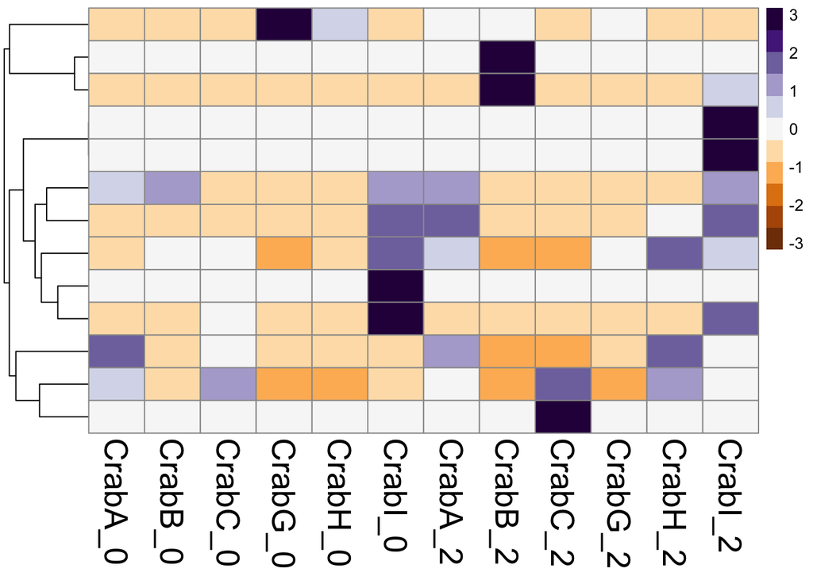

```r
pheatmap(noz_abcghi.heatmap, scale = "row", cluster_row = TRUE, cluster_cols = FALSE, clustering_distance_rows = "euclidean", clustering_method = "average", show_rownames = FALSE, show_colnames = TRUE, treeheight_col = 80, legend = TRUE, color = heatmapPurOr, fontsize_col = 20, fontsize_row = 12)
```

### Just crab ABC over time:

```r
abc <- select(contrasttemp_degs_counts_match, Trinity_ID, CrabA_0,  CrabB_0, CrabC_0, CrabA_2, CrabB_2, CrabC_2, CrabA_17, CrabB_17, CrabC_17)
head(abc)
```

```
##                 Trinity_ID CrabA_0 CrabB_0 CrabC_0 CrabA_2 CrabB_2 CrabC_2
## 1   TRINITY_DN276_c0_g1_i3   0.000   0.000   0.000   0.000   0.000   0.000
## 2 TRINITY_DN12397_c1_g1_i1   8.949  10.554   1.052  11.554   0.000   0.000
## 3  TRINITY_DN1968_c0_g1_i3   0.000   0.000   0.000   4.575   0.000   0.000
## 4 TRINITY_DN10286_c0_g1_i1   0.000   0.000   0.000   0.000   7.156   0.000
## 5  TRINITY_DN6714_c0_g1_i3   1.047   6.017   4.294   7.648   0.000   0.455
## 6  TRINITY_DN1536_c0_g1_i1   0.000   0.000   0.000   0.000   0.000   0.000
##   CrabA_17 CrabB_17 CrabC_17
## 1        0    0.000    0.000
## 2        0    2.159    3.889
## 3        0    0.000    3.118
## 4        0    1.856    0.000
## 5        0    9.072   10.937
## 6        0    0.000    0.000
```

Set Trinity_ID as row names:

```r
rownames(abc) <- abc$Trinity_ID #set Trinity IDs as rownames
abc.heatmap <- abc[,-1] #remove redundant column
head(abc.heatmap)
```

```
##                          CrabA_0 CrabB_0 CrabC_0 CrabA_2 CrabB_2 CrabC_2
## TRINITY_DN276_c0_g1_i3     0.000   0.000   0.000   0.000   0.000   0.000
## TRINITY_DN12397_c1_g1_i1   8.949  10.554   1.052  11.554   0.000   0.000
## TRINITY_DN1968_c0_g1_i3    0.000   0.000   0.000   4.575   0.000   0.000
## TRINITY_DN10286_c0_g1_i1   0.000   0.000   0.000   0.000   7.156   0.000
## TRINITY_DN6714_c0_g1_i3    1.047   6.017   4.294   7.648   0.000   0.455
## TRINITY_DN1536_c0_g1_i1    0.000   0.000   0.000   0.000   0.000   0.000
##                          CrabA_17 CrabB_17 CrabC_17
## TRINITY_DN276_c0_g1_i3          0    0.000    0.000
## TRINITY_DN12397_c1_g1_i1        0    2.159    3.889
## TRINITY_DN1968_c0_g1_i3         0    0.000    3.118
## TRINITY_DN10286_c0_g1_i1        0    1.856    0.000
## TRINITY_DN6714_c0_g1_i3         0    9.072   10.937
## TRINITY_DN1536_c0_g1_i1         0    0.000    0.000
```

ROUND INTEGERS UP:

```r
abc.heatmap <- round(abc.heatmap,0)
head(abc.heatmap)
```

```
##                          CrabA_0 CrabB_0 CrabC_0 CrabA_2 CrabB_2 CrabC_2
## TRINITY_DN276_c0_g1_i3         0       0       0       0       0       0
## TRINITY_DN12397_c1_g1_i1       9      11       1      12       0       0
## TRINITY_DN1968_c0_g1_i3        0       0       0       5       0       0
## TRINITY_DN10286_c0_g1_i1       0       0       0       0       7       0
## TRINITY_DN6714_c0_g1_i3        1       6       4       8       0       0
## TRINITY_DN1536_c0_g1_i1        0       0       0       0       0       0
##                          CrabA_17 CrabB_17 CrabC_17
## TRINITY_DN276_c0_g1_i3          0        0        0
## TRINITY_DN12397_c1_g1_i1        0        2        4
## TRINITY_DN1968_c0_g1_i3         0        0        3
## TRINITY_DN10286_c0_g1_i1        0        2        0
## TRINITY_DN6714_c0_g1_i3         0        9       11
## TRINITY_DN1536_c0_g1_i1         0        0        0
```

Going to remove all rows that have “0” for all samples:

```r
noz_abc.heatmap <- abc.heatmap[rowSums(abc.heatmap[, -1] >0) !=0, ]
head(noz_abc.heatmap)
```

```
##                          CrabA_0 CrabB_0 CrabC_0 CrabA_2 CrabB_2 CrabC_2
## TRINITY_DN12397_c1_g1_i1       9      11       1      12       0       0
## TRINITY_DN1968_c0_g1_i3        0       0       0       5       0       0
## TRINITY_DN10286_c0_g1_i1       0       0       0       0       7       0
## TRINITY_DN6714_c0_g1_i3        1       6       4       8       0       0
## TRINITY_DN1968_c0_g1_i1       17       9      22      15       6      27
## TRINITY_DN5253_c0_g1_i1        0       0       0       0       0       9
##                          CrabA_17 CrabB_17 CrabC_17
## TRINITY_DN12397_c1_g1_i1        0        2        4
## TRINITY_DN1968_c0_g1_i3         0        0        3
## TRINITY_DN10286_c0_g1_i1        0        2        0
## TRINITY_DN6714_c0_g1_i3         0        9       11
## TRINITY_DN1968_c0_g1_i1         0       16       13
## TRINITY_DN5253_c0_g1_i1         0        0        0
```

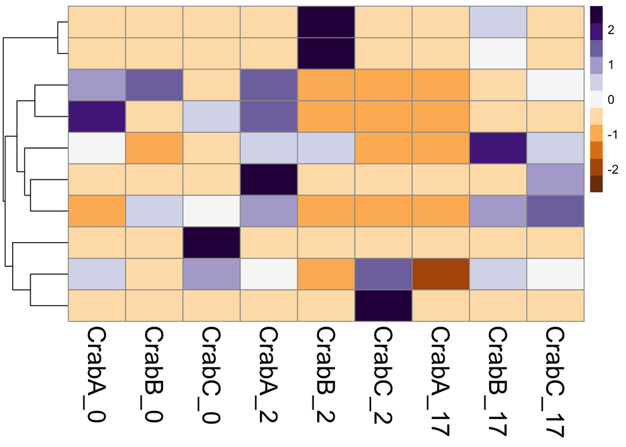

```r
pheatmap(noz_abc.heatmap, scale = "row", cluster_row = TRUE, cluster_cols = FALSE, clustering_distance_rows = "euclidean", clustering_method = "average", show_rownames = FALSE, show_colnames = TRUE, treeheight_col = 80, legend = TRUE, color = heatmapPurOr, fontsize_col = 20, fontsize_row = 12)
```

qPCR results from each crab:  
Crab A –> starting quantity of Hemat: 1119 Crab B –> starting quantity of Hemat: 105477 Crab C –> starting quantity of Hemat: 333000

#### Same heatmap, but with AAA BBB and CCC grouped together across time

```r
abc2 <- select(contrasttemp_degs_counts_match, Trinity_ID, CrabA_0,  CrabA_2, CrabA_17, CrabB_0, CrabB_2, CrabB_17, CrabC_0, CrabC_2, CrabC_17)
head(abc2)
```

```
##                 Trinity_ID CrabA_0 CrabA_2 CrabA_17 CrabB_0 CrabB_2 CrabB_17
## 1   TRINITY_DN276_c0_g1_i3   0.000   0.000        0   0.000   0.000    0.000
## 2 TRINITY_DN12397_c1_g1_i1   8.949  11.554        0  10.554   0.000    2.159
## 3  TRINITY_DN1968_c0_g1_i3   0.000   4.575        0   0.000   0.000    0.000
## 4 TRINITY_DN10286_c0_g1_i1   0.000   0.000        0   0.000   7.156    1.856
## 5  TRINITY_DN6714_c0_g1_i3   1.047   7.648        0   6.017   0.000    9.072
## 6  TRINITY_DN1536_c0_g1_i1   0.000   0.000        0   0.000   0.000    0.000
##   CrabC_0 CrabC_2 CrabC_17
## 1   0.000   0.000    0.000
## 2   1.052   0.000    3.889
## 3   0.000   0.000    3.118
## 4   0.000   0.000    0.000
## 5   4.294   0.455   10.937
## 6   0.000   0.000    0.000
```

Set Trinity_ID as row names:

```r
rownames(abc2) <- abc2$Trinity_ID #set Trinity IDs as rownames
abc2.heatmap <- abc2[,-1] #remove redundant column
head(abc2.heatmap)
```

```
##                          CrabA_0 CrabA_2 CrabA_17 CrabB_0 CrabB_2 CrabB_17
## TRINITY_DN276_c0_g1_i3     0.000   0.000        0   0.000   0.000    0.000
## TRINITY_DN12397_c1_g1_i1   8.949  11.554        0  10.554   0.000    2.159
## TRINITY_DN1968_c0_g1_i3    0.000   4.575        0   0.000   0.000    0.000
## TRINITY_DN10286_c0_g1_i1   0.000   0.000        0   0.000   7.156    1.856
## TRINITY_DN6714_c0_g1_i3    1.047   7.648        0   6.017   0.000    9.072
## TRINITY_DN1536_c0_g1_i1    0.000   0.000        0   0.000   0.000    0.000
##                          CrabC_0 CrabC_2 CrabC_17
## TRINITY_DN276_c0_g1_i3     0.000   0.000    0.000
## TRINITY_DN12397_c1_g1_i1   1.052   0.000    3.889
## TRINITY_DN1968_c0_g1_i3    0.000   0.000    3.118
## TRINITY_DN10286_c0_g1_i1   0.000   0.000    0.000
## TRINITY_DN6714_c0_g1_i3    4.294   0.455   10.937
## TRINITY_DN1536_c0_g1_i1    0.000   0.000    0.000
```

ROUND INTEGERS UP:

```r
abc2.heatmap <- round(abc2.heatmap,0)
head(abc2.heatmap)
```

```
##                          CrabA_0 CrabA_2 CrabA_17 CrabB_0 CrabB_2 CrabB_17
## TRINITY_DN276_c0_g1_i3         0       0        0       0       0        0
## TRINITY_DN12397_c1_g1_i1       9      12        0      11       0        2
## TRINITY_DN1968_c0_g1_i3        0       5        0       0       0        0
## TRINITY_DN10286_c0_g1_i1       0       0        0       0       7        2
## TRINITY_DN6714_c0_g1_i3        1       8        0       6       0        9
## TRINITY_DN1536_c0_g1_i1        0       0        0       0       0        0
##                          CrabC_0 CrabC_2 CrabC_17
## TRINITY_DN276_c0_g1_i3         0       0        0
## TRINITY_DN12397_c1_g1_i1       1       0        4
## TRINITY_DN1968_c0_g1_i3        0       0        3
## TRINITY_DN10286_c0_g1_i1       0       0        0
## TRINITY_DN6714_c0_g1_i3        4       0       11
## TRINITY_DN1536_c0_g1_i1        0       0        0
```

Going to remove all rows that have “0” for all samples:

```r
noz_abc2.heatmap <- abc2.heatmap[rowSums(abc2.heatmap[, -1] >0) !=0, ]
head(noz_abc2.heatmap)
```

```
##                          CrabA_0 CrabA_2 CrabA_17 CrabB_0 CrabB_2 CrabB_17
## TRINITY_DN12397_c1_g1_i1       9      12        0      11       0        2
## TRINITY_DN1968_c0_g1_i3        0       5        0       0       0        0
## TRINITY_DN10286_c0_g1_i1       0       0        0       0       7        2
## TRINITY_DN6714_c0_g1_i3        1       8        0       6       0        9
## TRINITY_DN1968_c0_g1_i1       17      15        0       9       6       16
## TRINITY_DN5253_c0_g1_i1        0       0        0       0       0        0
##                          CrabC_0 CrabC_2 CrabC_17
## TRINITY_DN12397_c1_g1_i1       1       0        4
## TRINITY_DN1968_c0_g1_i3        0       0        3
## TRINITY_DN10286_c0_g1_i1       0       0        0
## TRINITY_DN6714_c0_g1_i3        4       0       11
## TRINITY_DN1968_c0_g1_i1       22      27       13
## TRINITY_DN5253_c0_g1_i1        0       9        0
```

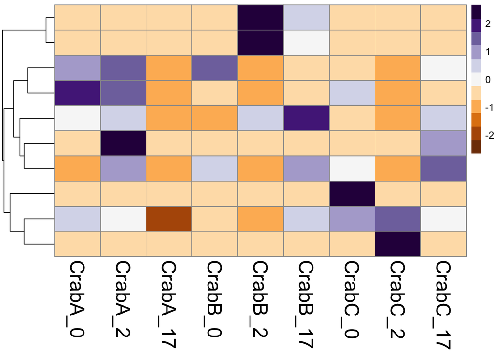

```r
pheatmap(noz_abc2.heatmap, scale = "row", cluster_row = TRUE, cluster_cols = FALSE, clustering_distance_rows = "euclidean", clustering_method = "average", show_rownames = FALSE, show_colnames = TRUE, treeheight_col = 80, legend = TRUE, color = heatmapPurOr, fontsize_col = 20, fontsize_row = 12)
```